[figure not shown]

# Grado en Ciencia de Datos.

## Práctica 5. Ensembles: bagging de clasificación, de regresión y Random Forest.

#### Andreu Cantó y Amparo Gálvez

En los métodos combinados (métodos de *ensemble*), el modelo final está formado por la combinación de diferentes modelos individuales y suelen ofrecer mejor rendimiento que los modelos individuales. Pueden estar formados por modelos del mismo o de diferente tipo, pero es muy importante que los modelos sean complementarios, es decir, que estén poco correlacionados. Para combinarlos, en clasificación se suele utilizar el voto mayoritario mientras que en regresión se utiliza una medida de centralización, como la media.

En esta práctica vamos a realizar *ensembles* de árboles de decisión, que individualmente son inestables (pueden cambiar bastante con un pequeño cambio en el conjunto de datos), pero con *ensembles* son mucho más estables.

```python
%load_ext autoreload
%autoreload 2
%matplotlib inline
```

### Bagging para clasificación

Hay varias formas de construir ensembles (votación por mayoría, *bagging, boosting*...). En la práctica veremos el método de *bagging*, que consiste en entrenar cada modelo con subconjuntos del conjunto de entrenamiento. Estos subconjuntos se forman eligiendo muestras aleatoriamente (con reemplazo) del conjunto de entrenamiento.

Podéis encontrar más información sobre la implementación de *bagging* para clasificación mediante sklearn en el siguiente enlace:

https://scikit-learn.org/stable/modules/generated/sklearn.ensemble.BaggingClassifier.html

#### Empezaremos generando datos "juguete" para hacer un ejemplo.

```python
import numpy as np
import matplotlib.pyplot as plt

from sklearn.datasets import make_moons, make_checkerboard
from sklearn.datasets import load_iris, load_digits
from sklearn.tree import DecisionTreeClassifier
from sklearn.naive_bayes import GaussianNB
from sklearn.model_selection import train_test_split
from sklearn.utils import resample
from sklearn import metrics
from scipy.stats import mode
from sklearn.metrics import mean_squared_error
from sklearn.ensemble import RandomForestRegressor
```

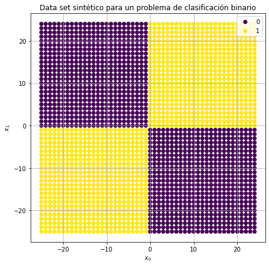

```python
# Read and show dataset(s)

N = 50
X = np.arange(N) - N/2
x1, x2 = np.meshgrid(X, X)
X = np.c_[x1.ravel(), x2.ravel()]
y = np.zeros(N * N)
y[(X[:,0] >= 0) * (X[:,1] >= 0 )] = 1
y[(X[:,0]  < 0) * (X[:,1]  < 0 )] = 1

#Convertimos a entero, clase 0 y clase 1
y=y.astype('int')

fig,ax = plt.subplots(figsize=(7,7))
sc=ax.scatter(X[:,0], X[:,1], c=y)
ax.set_xlabel('$x_0$')
ax.set_ylabel('$x_1$')
ax.set_title('Data set sintético para un problema de clasificación binario')

h, l = sc.legend_elements()
ax.legend(h,np.unique(y)), plt.grid(1);
```

```python
# Setup predictor, árbol de clasificació
clasificador = DecisionTreeClassifier
criterion = 'entropy'
max_depth = 2  # 1  # None  # 2
#Utilizamos la función metrics.classification_report para evaluar el clasificador
report = metrics.classification_report
```

```python
# Divide into training and test sets
Xtr, Xts, ytr, yts = train_test_split(X, y, test_size=0.3, random_state=6)
```

#### Clasificamos utilizando únicamente un árbol.

```python
# Create a single predictor (for reference)
tree = clasificador(criterion=criterion, max_depth=max_depth, random_state=0)
# Train / prediction of single predictor
tree.fit(Xtr, ytr)
yp = tree.predict(Xts)
print('Res tree:', report(yts, yp))
```

```
Res tree:               precision    recall  f1-score   support

           0       0.52      0.59      0.55       356
           1       0.58      0.50      0.54       394

    accuracy                           0.55       750
   macro avg       0.55      0.55      0.55       750
weighted avg       0.55      0.55      0.54       750
```

#### Clasificamos utilizando bagging.

**Ejercicio.** Crea un bosque usando muchos árboles, por ejemplo 100. Para ello:

1. Decide cuantos árboles tendrá tu bosque y guárdalo en la variable `T`.
2. Cre una variable llamada `bag` que sea una lista para guardarte los árboles.
3. Crea un bucle donde entrenes cada unos de los árboles con un subset aleatorio de tus datos. Para crear el subset emplea la función `resample`.
4. Cada vez que pases por el bucle guárdate el árbol entrenado en la variable `bag`.

```python
T = 100

bag = []

for i in range(T):
    X_subset, y_subset = resample(X, y, replace = True)

    tree = clasificador(criterion=criterion, max_depth=max_depth, random_state=0)
    tree.fit(X_subset, y_subset)

    bag.append(tree)
```

**Ejercicio.** Predice con los datos de test usando la moda de lo que clasifica cada árbol para cada muestra. Ayuda: Usa la funcion "mode".

```python
preds = np.zeros((len(bag), len(Xts)))

for i, tree in enumerate(bag):
    preds[i, :] = tree.predict(Xts)

moda = mode(preds, axis = 0)

y_pred = moda.mode[0]
n_votos = moda.count[0]

v0 = n_votos[y_pred == 0]
v1 = n_votos[y_pred == 1]
```

**Ejercicio.** Representa el reparto de votos en el bosque mediante la función `hist` empleando 20 bins. Compara los histogramas obtenidos para cada clase.

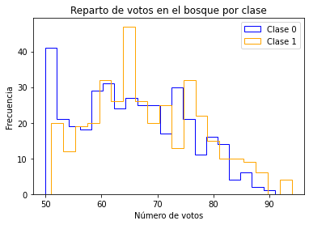

```python
plt.hist(v0, bins=20, alpha=1, histtype='step', color='blue', label='Clase 0')

plt.hist(v1, bins=20, alpha=1, histtype='step', color='orange', label='Clase 1')

plt.xlabel('Número de votos')
plt.ylabel('Frecuencia')
plt.title('Reparto de votos en el bosque por clase')
plt.legend()

plt.show()
```

En el siguiente código tienes la implementación con las funciones de sklearn

```python
# Usando el bagging de sklearn
from sklearn.ensemble import BaggingClassifier
bc = BaggingClassifier(base_estimator=clasificador(criterion=criterion, \
                        max_depth=max_depth), n_estimators=100)
bc.fit(Xtr, ytr)
yc = bc.predict(Xts)
```

**Ejercicio.** Compara los resultados con un sólo árbol y con bagging manual y sklearn ¿Cuál funciona mejor?

```python
print("Score para bagging con un solo árbol", metrics.accuracy_score(yts,yp))
print("Score para bagging manual", metrics.accuracy_score(yts,y_pred))
print("Score para bagging sklearn", metrics.accuracy_score(yts,yc))
```

```
Score para bagging con un solo árbol 0.5453333333333333
Score para bagging manual 0.96
Score para bagging sklearn 0.9893333333333333
```

**Ejercicio.** Evalúa el algoritmo (emplea la métrica `metrics.accuracy_score`) para distinto número de árboles y crea una gráfica del error frente al número de árboles ¿Qué ocurre con el error conforme se usan más árboles? Ayuda: Toma valores de 1 a 100 árboles en el bosque.

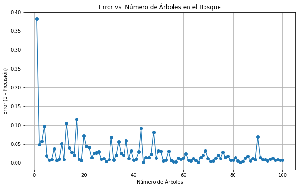

```python
num_trees = range(1, 101)

accuracy_scores = []

for i in num_trees:
    bc = BaggingClassifier(base_estimator=clasificador(criterion=criterion, \
                        max_depth=max_depth), n_estimators=i)
    bc.fit(Xtr, ytr)
    yc = bc.predict(Xts)
    ac_score = metrics.accuracy_score(yts,yc)
    accuracy_scores.append(1-ac_score)

plt.figure(figsize=(10, 6))
plt.plot(num_trees, accuracy_scores, marker='o', linestyle='-')
plt.title('Error vs. Número de Árboles en el Bosque')
plt.xlabel('Número de Árboles')
plt.ylabel('Error (1 - Precisión)')
plt.grid(True)
plt.show()
```

### Bagging para regresión

Podéis encontrar más información sobre la implementación de *bagging* para regresión mediante sklearn en el siguiente enlace:

https://scikit-learn.org/stable/modules/generated/sklearn.ensemble.BaggingRegressor.html

```python
import numpy as np
import matplotlib.pyplot as plt

from sklearn.datasets import load_boston, load_diabetes, load_linnerud
from sklearn.tree import DecisionTreeRegressor
from sklearn.linear_model import LinearRegression
from sklearn.model_selection import train_test_split
from sklearn.utils import resample
from sklearn import metrics
from scipy.stats import mode as moda
```

Preparamos los datos juguete con la función *sinc* utilizada en la práctica anterior.

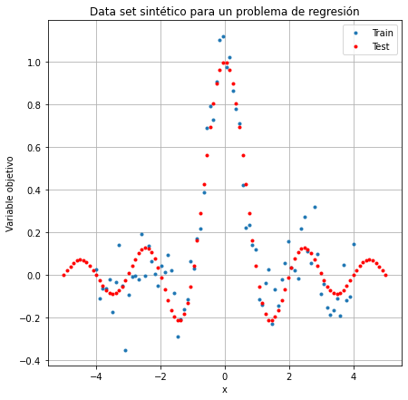

```python
#Generamos una sinc....

X = np.linspace(-5, 5, 100)[:, None]
y = np.sinc(X)

# Metemos ruido en los datos de entrenamiento
pcut = 4
noise = 0.1
Xtr = X[(-pcut <= X) & (X <= pcut)][:, None]
ytr = y[(-pcut <= X) & (X <= pcut)][:, None]
ytr = ytr + noise * np.random.randn(ytr.shape[0], 1)
Xts = X; yts = y


fig,ax = plt.subplots(figsize=(7,7))
ax.plot(Xtr, ytr, '.')
ax.plot(Xts, yts, 'r.')
ax.set_xlabel('x')
ax.set_ylabel('Variable objetivo')
ax.set_title('Data set sintético para un problema de regresión')
ax.legend(['Train','Test'])
plt.grid(1);
```

**Ejercicio.** Entrena y predice mediante un árbol de regresión usando como criterio 'squared_error'. Muestra los resultados gráficamente.

```python
# Definimos el predictor! Cuidado, aquí report es mean_squared_error!!
predictor = DecisionTreeRegressor
criterion = 'squared_error'
max_depth = None
report = metrics.mean_squared_error
```

```python
tree_regressor = DecisionTreeRegressor(random_state=0)
tree_regressor.fit(Xtr, ytr)

y_pred = tree_regressor.predict(Xts)

mse = report(yts, y_pred)
print('MSE: ', mse)
```

```
MSE:  0.009976911331391046
```

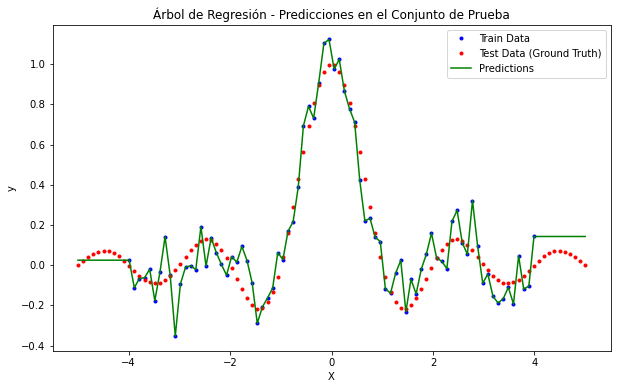

```python
# Muestra los resultados de las predicciones en test graficamente
plt.figure(figsize=(10, 6))

plt.plot(Xtr, ytr, 'b.', label='Train Data')
plt.plot(Xts, yts, 'r.', label='Test Data (Ground Truth)')
plt.plot(Xts, y_pred, 'g', label='Predictions')

plt.title('Árbol de Regresión - Predicciones en el Conjunto de Prueba')
plt.xlabel('X')
plt.ylabel('y')
plt.legend()
plt.show()
```

**Ejercicio.** Crea un bosque usando 200 árboles. Muestra los resultados gráficamente. ¿Qué funciona mejor el árbol o el bosque?. Implementa el bosque empleando sklearn. Puedes hacerlo también manualmente, si lo haces recuerda que el criterio para hacer la predicción es la media (en clasificación se optaba por la moda).

```python
# Que implementen manual o sklearn, preferiblemente con sklearn.
#Quien quiera que haga los dos ...

# Bagging manual --> mismo código que para clasificación pero cambia
# el predictor, en este caso DecisionTreeRegressor
# y en la predicción en vez de utilizar la moda se hace la media

tree_regressor = DecisionTreeRegressor(random_state=0)
tree_regressor.fit(Xtr, ytr)
y_pred_tree = tree_regressor.predict(Xts)
mse_tree = mean_squared_error(yts, y_pred_tree)

T = 200
bag = []

for _ in range(T):
    indices_subset = np.random.choice(range(Xtr.shape[0]), size=Xtr.shape[0], replace=True)
    X_subset, y_subset = Xtr[indices_subset], ytr[indices_subset]

    tree = DecisionTreeRegressor(random_state=0)
    tree.fit(X_subset, y_subset)

    bag.append(tree)

y_pred_bagging_manual = np.mean([tree.predict(Xts) for tree in bag], axis=0)

mse_bagging_manual = mean_squared_error(yts, y_pred_bagging_manual)

forest_regressor = RandomForestRegressor(n_estimators=200, random_state=0)
forest_regressor.fit(Xtr, ytr.ravel())
y_pred_bagging_sklearn = forest_regressor.predict(Xts)
mse_bagging_sklearn = mean_squared_error(yts, y_pred_bagging_sklearn)

print("MSE Árbol:", mse_tree)
print("MSE Bosque Manual:", mse_bagging_manual)
print("MSE Bosque Sklearn:", mse_bagging_sklearn)
```

```
MSE Árbol: 0.009976911331391046
MSE Bosque Manual: 0.005761024616831759
MSE Bosque Sklearn: 0.005768651146204216
```

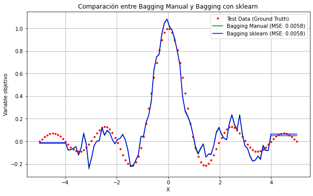

```python
plt.figure(figsize=(10, 6))

#Datos de prueba y predicciones
plt.plot(Xts, yts, 'r.', label='Test Data (Ground Truth)')
plt.plot(Xts, y_pred_bagging_manual, 'g-', label=f'Bagging Manual (MSE: {mse_bagging_manual:.4f})')
plt.plot(Xts, y_pred_bagging_sklearn, 'b-', label=f'Bagging sklearn (MSE: {mse_bagging_sklearn:.4f})')

plt.xlabel('X')
plt.ylabel('Variable objetivo')
plt.title('Comparación entre Bagging Manual y Bagging con sklearn')
plt.legend()
plt.grid(True)
plt.show()
```

Observamos que la disparidad entre emplear bagging de forma manual o a través de sklearn, se nota que ambos métodos son confiables, ya que se adaptan de manera precisa a los datos.

**Ejercicio.** Compara los resultados obtenidos con un sólo árbol con los del bosque mediante una gráfica y utilizando el coeficiente de determinación $R^2$ empleando la función `r2_score`de sklearn.

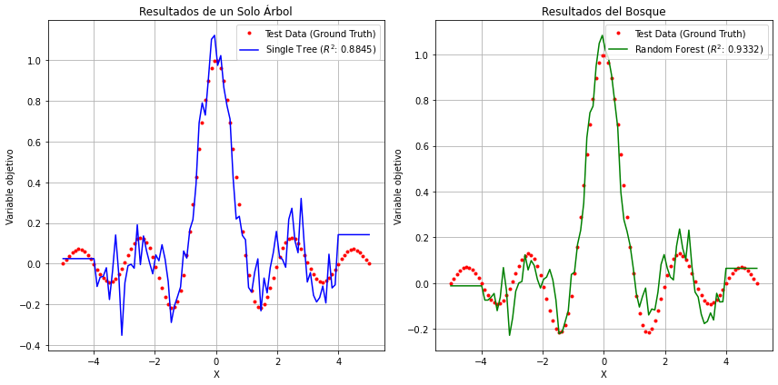

```python
from sklearn.metrics import r2_score

r2_tree = r2_score(yts, y_pred_tree)
r2_forest = r2_score(yts, y_pred_bagging_sklearn)

plt.figure(figsize=(12, 6))

plt.subplot(1, 2, 1)
plt.plot(Xts, yts, 'r.', label='Test Data (Ground Truth)')
plt.plot(Xts, y_pred_tree, 'b-', label=f'Single Tree ($R^2$: {r2_tree:.4f})')
plt.xlabel('X')
plt.ylabel('Variable objetivo')
plt.title('Resultados de un Solo Árbol')
plt.legend()
plt.grid(True)

plt.subplot(1, 2, 2)
plt.plot(Xts, yts, 'r.', label='Test Data (Ground Truth)')
plt.plot(Xts, y_pred_bagging_sklearn, 'g-', label=f'Random Forest ($R^2$: {r2_forest:.4f})')
plt.xlabel('X')
plt.ylabel('Variable objetivo')
plt.title('Resultados del Bosque')
plt.legend()
plt.grid(True)
plt.tight_layout()
plt.show()
```

Notamos que ambos modelos son bastante efectivos, y el modelo de bosque muestra un rendimiento ligeramente superior al modelo de un solo árbol.

**Ejercicio.** Representa las predicciones frente al valor real para las tres aproximaciones, compara los resultados con una recta de pendiente unidad y ordenada en el origen 0.

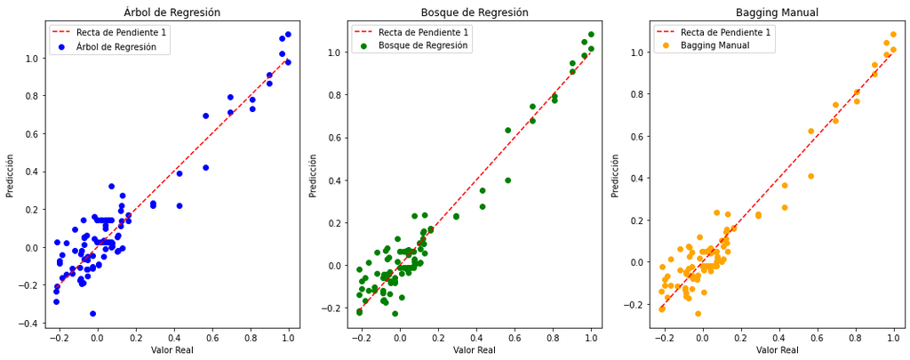

```python
# Compara los tres métodos gráficamente

plt.figure(figsize=(15, 6))

# Arbol de regresión
plt.subplot(1, 3, 1)
plt.scatter(yts, y_pred_tree, color='blue', label='Árbol de Regresión')
plt.plot([min(yts), max(yts)], [min(yts), max(yts)], '--', color='red', label='Recta de Pendiente 1')
plt.xlabel('Valor Real')
plt.ylabel('Predicción')
plt.title('Árbol de Regresión')
plt.legend()

# Sklearn
plt.subplot(1, 3, 2)
plt.scatter(yts, y_pred_bagging_sklearn, color='green', label='Bosque de Regresión')
plt.plot([min(yts), max(yts)], [min(yts), max(yts)], '--', color='red', label='Recta de Pendiente 1')
plt.xlabel('Valor Real')
plt.ylabel('Predicción')
plt.title('Bosque de Regresión')
plt.legend()

# Manual
plt.subplot(1, 3, 3)
plt.scatter(yts, y_pred_bagging_manual, color='orange', label='Bagging Manual')
plt.plot([min(yts), max(yts)], [min(yts), max(yts)], '--', color='red', label='Recta de Pendiente 1')
plt.xlabel('Valor Real')
plt.ylabel('Predicción')
plt.title('Bagging Manual')
plt.legend()

plt.tight_layout()
plt.show()
```

### Random Forest

Los bosques aleatorios (Random Forests), no son ni más ni menos, que un ensemble de árboles de decisión combinados con bagging. En cada nodo:

1. Se seleccionan $m$ variables de manera aleatoria entre las $M$ posibles variables.
2. Se encuentra la mejor separación en ramas de este nodo utilizando únicamente las $m$ variables.

Se hacen crecer los árboles hasta su máxima profundidad.

Las predicciones para nuevos datos se realizan como en los ejercicios de bagging de los apartados anteriores: mediante votación para clasificación o promediando para regresión.

En este apartado aplicaremos Random Forest para regresión. Puedes encontrar más información sobre su implementación en sklearn en el siguiente enlace:

https://scikit-learn.org/stable/modules/generated/sklearn.ensemble.RandomForestRegressor.html

```python
import numpy as np
import matplotlib.pyplot as plt

from sklearn.datasets import load_boston, load_diabetes, load_linnerud
from sklearn.tree import DecisionTreeRegressor
from sklearn.linear_model import LinearRegression
from sklearn.model_selection import train_test_split
from sklearn.ensemble import RandomForestRegressor
from sklearn.utils import resample
from sklearn import metrics
from scipy.stats import mode as moda
```

Vamos a aplicar la técnica de Random Forest con el dataset de diabetes.

```python
# Preparamos datos...
X, y = load_diabetes(return_X_y=True)
Xtr, Xts, ytr, yts = train_test_split(X, y, test_size=0.3)
```

**Ejercicio.** Implementa el algoritmo de Random Forest y realiza la predicción. Es igual que el de Bagging pero en este caso se limita el número de características utilizadas en cada nodo para tomar la decisión. En lugar de usarlas todas como hasta ahora se cogen unas pocas aleatoriamente.

- Para regresión se usa típicamente: max_features = "sqrt"
- Para clasificación se usa típicamente: max_features = "log2"

```python
predictor = DecisionTreeRegressor
# predictor = LinearRegression
criterion = 'squared_error'
max_depth = None
max_features = "sqrt"
report = metrics.mean_squared_error
```

```python
## Con un solo árbol
tree_regressor = DecisionTreeRegressor(max_depth=max_depth, random_state=0)
tree_regressor.fit(Xtr, ytr)

#Realizamos predicciones en el conjunto de prueba
y_pred_tree = tree_regressor.predict(Xts)

#Calculamos el error cuadrático medio
mse_tree = report(yts, y_pred_tree)
print('MSE de un árbol: ', mse_tree)
```

```
MSE de un árbol:  6524.481203007519
```

```python
# Train bagging ensemble
T = 100 # T = number of trees
bag = [] # bag  variable to store the trees (for ex., a list)
# loop for the number of trees
for _ in range(T):
    # resample(X, Y, replace=True)
    X_subset, y_subset = resample(Xtr, ytr, replace=True, random_state=_)

    tree = DecisionTreeRegressor(max_depth=max_depth, random_state=0)
    tree.fit(X_subset, y_subset)

    bag.append(tree)

y_pred_bagging_manual = np.mean([tree.predict(Xts) for tree in bag], axis=0)

mse_bagging_manual = mean_squared_error(yts, y_pred_bagging_manual)
print('MSE de manual: ', mse_bagging_manual)
```

```
MSE de manual:  3148.140818796993
```

**Ejercicio.** Implementa el algoritmo de Random Forest con sklearn y compara el error obtenido con el error usando un único árbol.

```python
n_estimators = 100

rf_regressor = RandomForestRegressor(n_estimators=n_estimators, max_features=max_features, random_state=0)
rf_regressor.fit(Xtr, ytr)

y_pred_bagging_sklearn = rf_regressor.predict(Xts)

mse_bagging_sklearn = mean_squared_error(yts, y_pred_bagging_sklearn)
print('MSE de sklearn: ',mse_bagging_sklearn)
```

[output not shown]

**Ejercicio.** Averigua qué hace cada uno de los siguientes parámetros:

- n_estimators
- max_depth
- max_features
- bootstrap

Intenta implementar en casa alguna estrategia de "grid search" variando esos parámetros para conseguir un modelo invencible!

- **n_estimators:** controla la cantidad de árboles que forman el bosque.
- **max_depth:** regula la profundidad máxima permitida para cada árbol en el bosque.
- **max_features:** fija el número máximo de características consideradas al realizar divisiones en los nodos de los árboles.
- **bootstrap:** decide si se emplean o no muestras de arranque (con reemplazo) durante la construcción de los árboles.

```python
from sklearn.ensemble import RandomForestRegressor
from sklearn.model_selection import GridSearchCV
from sklearn.metrics import make_scorer

rf_model = RandomForestRegressor()

param_grid = {
    'n_estimators': [50, 100, 200],
    'max_depth': [None, 10, 20],
    'max_features': ['auto', 'sqrt', 'log2'],
    'bootstrap': [True, False]}
scorer = make_scorer(mean_squared_error, greater_is_better=False)

grid_search = GridSearchCV(estimator=rf_model, param_grid=param_grid, cv=5, scoring=scorer)

grid_search.fit(Xtr, ytr)

print("Mejores Parámetros:", grid_search.best_params_)
print("Mejor Puntuación:", -grid_search.best_score_)

best_model = grid_search.best_estimator_

mse_test = mean_squared_error(yts, best_model.predict(Xts))
print("MSE en el conjunto de prueba:", mse_test)
```

[output not shown]